# Kickstarter Data Exploration

Ian Scarff

January 24, 2019

## Data

Use the 2018 data file for kickstarters.

```r
data <- read.csv("ks-projects-201801.csv")
View(data)
```

#### Variables

- Name
  - The name of the kickstarter project
- Category
  - Name of sub-catagory under main catagories
- Main_Catagory
  - Name of main catagories.
- Currancy
  - The type of currancy used in pledging money (3 letter abbreviations).
- Deadline
  - Date kickstarter wants monetary goal to be reached (year - month - day).
- Goal
  - The monetary goal set by the kickstarter (in terms of type of currancy).
- Launched
  - Date the kick starter was started (year - month - day hour:minute:second).
- Pledged
  - The amount of money given to the kickstarter (in terms of type of currancy).
- State
  - The current state of the kickstarter (Ex: successful, failed, … etc.).
- Backers
  - The number if people who gave money.
- Country
  - The country of kickstarter origin (2 letter abbreviations).
- Usd.Pledged
  - The amount of money pledged in terms of the U.S. Dollar (rounded).
- Usd_Pledged_Real
  - The true amount of money (not rounded) pledged in terms of the U.S. Dollar.
- Usd_Goal_Real
  - The true monetary goal (not rounded) set by the kickstarter in terms of the U.S. Dollar.

#### Structure

```r
str(data)
```

```
## 'data.frame':    378661 obs. of  15 variables:
##  $ ID              : int  1000002330 1000003930 1000004038 1000007540 1000011046 1000014025 1000023410 1000030581 1000034518 100004195 ...
##  $ name            : Factor w/ 375765 levels "","\177Not Twins - New EP! \"The View from Down Here\"",..: 332541 135689 365010 344805 77349 206130 293462 69360 284139 290718 ...
##  $ category        : Factor w/ 159 levels "3D Printing",..: 109 94 94 91 56 124 59 42 114 40 ...
##  $ main_category   : Factor w/ 15 levels "Art","Comics",..: 13 7 7 11 7 8 8 8 5 7 ...
##  $ currency        : Factor w/ 14 levels "AUD","CAD","CHF",..: 6 14 14 14 14 14 14 14 14 14 ...
##  $ deadline        : Factor w/ 3164 levels "2009-05-03","2009-05-16",..: 2288 3042 1333 1017 2247 2463 1996 2448 1790 1863 ...
##  $ goal            : num  1000 30000 45000 5000 19500 50000 1000 25000 125000 65000 ...
##  $ launched        : Factor w/ 378089 levels "1970-01-01 01:00:00",..: 243292 361975 80409 46557 235943 278600 187500 274014 139367 153766 ...
##  $ pledged         : num  0 2421 220 1 1283 ...
##  $ state           : Factor w/ 6 levels "canceled","failed",..: 2 2 2 2 1 4 4 2 1 1 ...
##  $ backers         : int  0 15 3 1 14 224 16 40 58 43 ...
##  $ country         : Factor w/ 23 levels "AT","AU","BE",..: 10 23 23 23 23 23 23 23 23 23 ...
##  $ usd.pledged     : num  0 100 220 1 1283 ...
##  $ usd_pledged_real: num  0 2421 220 1 1283 ...
##  $ usd_goal_real   : num  1534 30000 45000 5000 19500 ...
```

The launched and deadline variables should be set as date variables.

```r
data$deadline <- as.Date(data$deadline)
data$launched <- as.Date(data$launched)
```

What is the time range for these projects?

```r
range(data$deadline)
```

```
## [1] "2009-05-03" "2018-03-03"
```

```r
range(data$launched)
```

```
## [1] "1970-01-01" "2018-01-02"
```

Kickstarted was founded on April 28, 2009. Projects with launch dates in 1970 are not correct.

How many projects are there like this?

```r
which(data$launched == min(data$launched))
```

```
## [1]   2843  48148  75398  94580 247914 273780 319003
```

There are 7 such project. Remove them.

```r
data <- data[-c(which(data$launched == min(data$launched))), ]

range(data$launched)
```

```
## [1] "2009-04-21" "2018-01-02"
```

##### Factor Variables

Let’s look at some of the factor variables.

Main Categories

```r
levels(data$main_category)
```

```
##  [1] "Art"          "Comics"       "Crafts"       "Dance"
##  [5] "Design"       "Fashion"      "Film & Video" "Food"
##  [9] "Games"        "Journalism"   "Music"        "Photography"
## [13] "Publishing"   "Technology"   "Theater"
```

There are 15 main categories

```r
table(data$main_category)
```

```
##
##          Art       Comics       Crafts        Dance       Design
##        28152        10819         8809         3768        30069
##      Fashion Film & Video         Food        Games   Journalism
##        22816        63583        24602        35231         4755
##        Music  Photography   Publishing   Technology      Theater
##        51917        10779        39873        32569        10912
```

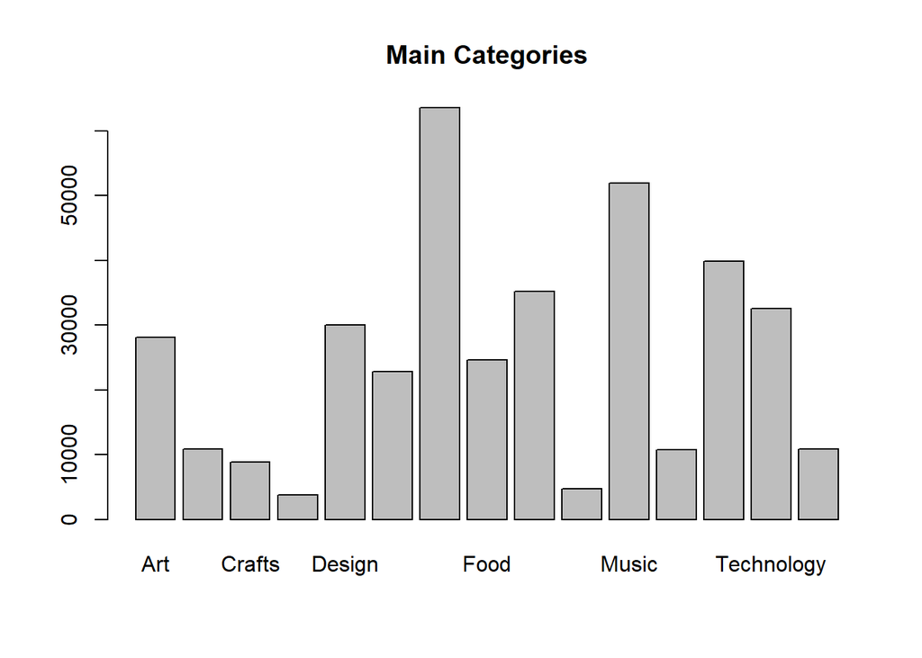

```r
barplot(table(data$main_category), main = "Main Categories")
```

Film & Video is the largest category

Sub Categories

```r
levels(data$category)
```

```
##   [1] "3D Printing"        "Academic"           "Accessories"
##   [4] "Action"             "Animals"            "Animation"
##   [7] "Anthologies"        "Apparel"            "Apps"
##  [10] "Architecture"       "Art"                "Art Books"
##  [13] "Audio"              "Bacon"              "Blues"
##  [16] "Calendars"          "Camera Equipment"   "Candles"
##  [19] "Ceramics"           "Children's Books"   "Childrenswear"
##  [22] "Chiptune"           "Civic Design"       "Classical Music"
##  [25] "Comedy"             "Comic Books"        "Comics"
##  [28] "Community Gardens"  "Conceptual Art"     "Cookbooks"
##  [31] "Country & Folk"     "Couture"            "Crafts"
##  [34] "Crochet"            "Dance"              "Design"
##  [37] "Digital Art"        "DIY"                "DIY Electronics"
##  [40] "Documentary"        "Drama"              "Drinks"
##  [43] "Electronic Music"   "Embroidery"         "Events"
```

[output cut: 38 more lines]

There are 159 sub categories across the 15 main categories

```r
table(data$category)
```

```
##
##        3D Printing           Academic        Accessories
##                683                916               3165
##             Action            Animals          Animation
##                740                255               2541
##        Anthologies            Apparel               Apps
##                784               7166               6345
##       Architecture                Art          Art Books
##                760               8252               2676
##              Audio              Bacon              Blues
##                410                221                268
##          Calendars   Camera Equipment            Candles
##                329                416                429
##           Ceramics   Children's Books      Childrenswear
##                305               6756                483
##           Chiptune       Civic Design    Classical Music
##                 35                289               2613
##             Comedy        Comic Books             Comics
##               2320               2743               4996
##  Community Gardens     Conceptual Art          Cookbooks
##                298               1030                540
##     Country & Folk            Couture             Crafts
##               4451                275               4664
##            Crochet              Dance             Design
##                162               2322               4198
##        Digital Art                DIY    DIY Electronics
##               1346               1173                902
##        Documentary              Drama             Drinks
##              16139               2179               2422
##   Electronic Music         Embroidery             Events
##               2170                113                818
##       Experimental  Fabrication Tools              Faith
##                924                250               1092
##             Family            Fantasy   Farmer's Markets
##                336                345                424
##              Farms            Fashion          Festivals
##               1154               8554                839
##            Fiction       Film & Video           Fine Art
##               9169              10106                776
##             Flight               Food        Food Trucks
```

[output cut: 52 more lines]

```
##                219              14180                 13
##         Technology         Television           Textiles
##               6930               1015                276
##            Theater          Thrillers       Translations
##               7056                746                153
##         Typography              Vegan              Video
##                108                588                428
##          Video Art        Video Games          Wearables
##                194              11830               1233
##            Weaving                Web          Webcomics
##                 93               5153                648
##          Webseries        Woodworking          Workshops
##               5762               1167                164
##        World Music        Young Adult              Zines
##               2102                821                391
```

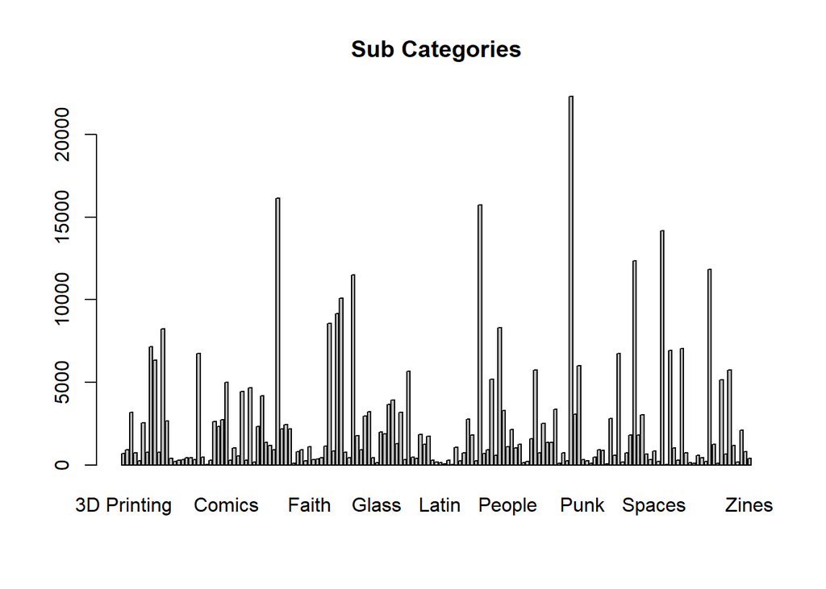

```r
barplot(table(data$category), main = "Sub Categories")
```

Product Design is the largest sub category

Currancy

```r
levels(data$currency)
```

```
##  [1] "AUD" "CAD" "CHF" "DKK" "EUR" "GBP" "HKD" "JPY" "MXN" "NOK" "NZD"
## [12] "SEK" "SGD" "USD"
```

There are 14 types of currancy

- AUD
  - Australian Dollar
- CAD
  - Canadian Dollar
- CHF
  - Swiss Frank
- DKK
  - Danich Krone
- EUR
  - Euro
- GBP
  - Great British Pound
- HKD
  - Hong Kong Dollar
- JPY
  - Japanese Yen
- MXN
  - Mexican Peso
- NOK
  - Norwegian Krone
- NZD
  - New Zealand Dollar
- SEK
  - Swedish Krona
- SGD
  - Singapore Dollar
- USD
  - United States Dollar

```r
### Make separate data frames for each currancy

aud <- length(which(data$currency == "AUD"))
cad <- length(which(data$currency == "CAD"))
chf <- length(which(data$currency == "CHF"))
dkk <- length(which(data$currency == "DKK"))
eur <- length(which(data$currency == "EUR"))
gbp <- length(which(data$currency == "GBP"))
hkd <- length(which(data$currency == "HKD"))
jpy <- length(which(data$currency == "JPY"))
mxn <- length(which(data$currency == "MXN"))
nok <- length(which(data$currency == "NOK"))
nzd <- length(which(data$currency == "NZD"))
sek <- length(which(data$currency == "SEK"))
sgd <- length(which(data$currency == "SGD"))
usd <- length(which(data$currency == "USD"))
```

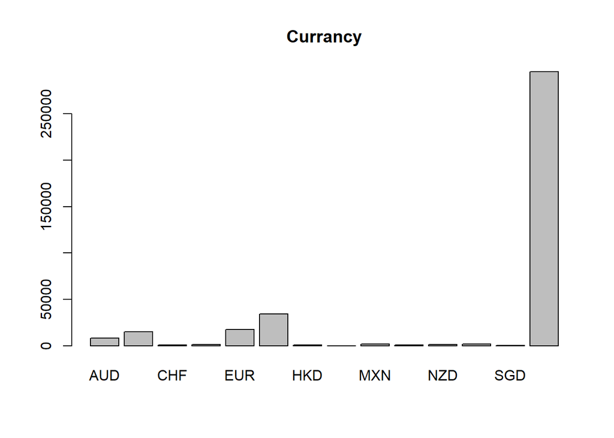

```r
barplot(table(data$currency), main = "Currancy")
```

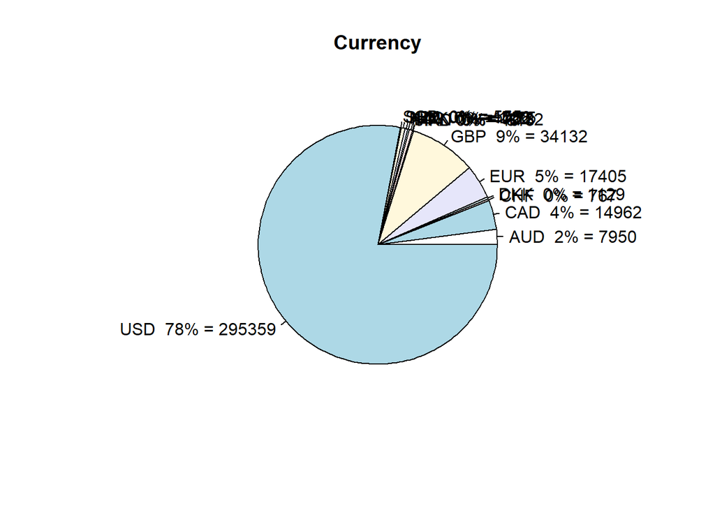

```
##  [1] "AUD  2% = 7950"    "CAD  4% = 14962"   "CHF  0% = 767"
##  [4] "DKK  0% = 1129"    "EUR  5% = 17405"   "GBP  9% = 34132"
##  [7] "HKD  0% = 618"     "JPY  0% = 40"      "MXN  0% = 1752"
## [10] "NOK  0% = 722"     "NZD  0% = 1475"    "SEK  0% = 1788"
## [13] "SGD  0% = 555"     "USD  78% = 295359"
```

```r
### This function makes a pie graph
### Takes in the size of each slice, the labels for each slice, and the title
makePie <- function(slices, labels, title){

  ### Calculates what percent a slice takes of whole
  percent <- round(slices/sum(slices)*100)

  ### Creates the final label
  labels <- paste(labels,percent, sep = "  ")
  labels <- paste(labels,"%",sep="")
  labels <- paste(labels,slices, sep = " = ")

  ### Generates pie graph
  pie(slices, labels = labels, main = title)

  ### Displays labels
  labels
}


### Set slices and labels
CUR.SLICES <- c(aud,cad,chf,dkk,eur,gbp,hkd,jpy,mxn,nok,nzd,sek,sgd,usd)
CUR.LABELS <- levels(data$currency)

### Make pie graph
makePie(CUR.SLICES, CUR.LABELS, "Currency")
```

The United States Dollar is the most used currancy.

State

```r
levels(data$state)
```

```
## [1] "canceled"   "failed"     "live"       "successful" "suspended"
## [6] "undefined"
```

- Canceled
  - A project was canceled before the deadline.
- Failed
  - A project did not make enough money by the deadline.
- Live
  - Projects that are currently on going.
- Successful
  - A project made or exceeded their goal by the deadline.
- Suspended
  - A project was suspended because it violated the terms & services of Kickstarter.

What is up with this undefined variable? Take a closer look.

```r
data.und <- data[data$state == "undefined",]
View(data.und)

head(data.und)
```

```
##             ID                                      name     category
## 170 1000694855             STREETFIGHTERZ WHEELIE MURICA Film & Video
## 329  100149523               Duncan Woods - Chameleon EP        Music
## 633 1003023003 The Making of Ashley Kelley's Debut Album        Music
## 648 1003130892              Butter Side Down Debut Album        Music
## 750 1003629045                   Chase Goehring debut EP        Music
## 825 1004013077  Spencer Capier Instrumental Project 2015        Music
##     main_category currency   deadline goal   launched pledged     state
## 170  Film & Video      USD 2014-09-20 6500 2014-08-06  555.00 undefined
## 329         Music      AUD 2015-08-25 4500 2015-08-04 4767.00 undefined
## 633         Music      USD 2015-04-09 3500 2015-03-10 3576.00 undefined
## 648         Music      USD 2015-11-26 6000 2015-11-02 7007.80 undefined
## 750         Music      USD 2016-03-21 3000 2016-02-23 3660.38 undefined
## 825         Music      CAD 2014-10-10 4000 2014-09-10 4760.00 undefined
##     backers country usd.pledged usd_pledged_real usd_goal_real
## 170       0    N,0"          NA           555.00       6500.00
## 329       0    N,0"          NA          3402.08       3211.53
## 633       0    N,0"          NA          3576.00       3500.00
## 648       0    N,0"          NA          7007.80       6000.00
## 750       0    N,0"          NA          3660.38       3000.00
## 825       0    N,0"          NA          4251.14       3572.39
```

The rows with an undefined state level have many other problems. A big problem is the country. They are labeled under a country with the title of N,0“, which is not a country. It can’t be a misspelling of Norway because of the varying types of currancy throughout the rows.

```r
nrow(data.und)
```

```
## [1] 3562
```

There is a miniscule amount of rows that contain undefinded values. Remove them.

```r
data <- data[data$state != "undefined",]
table(data$state)
```

```
##
##   canceled     failed       live successful  suspended  undefined
##      38773     197719       2799     133956       1845          0
```

They have been removed.

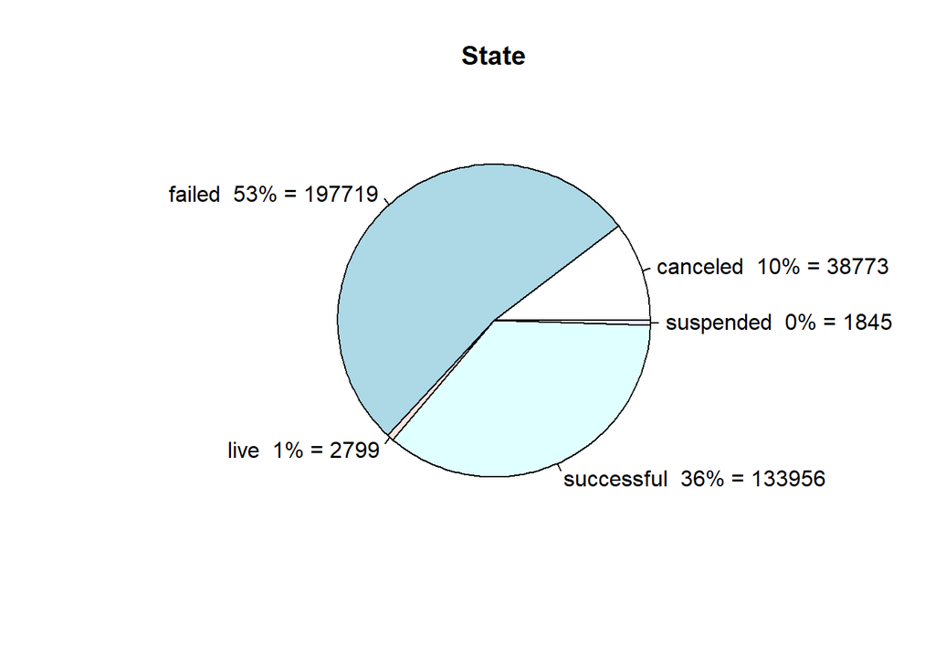

```
## [1] "canceled  10% = 38773"    "failed  53% = 197719"
## [3] "live  1% = 2799"          "successful  36% = 133956"
## [5] "suspended  0% = 1845"     "undefined  10% = 38773"
```

```r
### Make separate data frames for each state
CANC <- length(which(data$state == "canceled"))
FAIL <- length(which(data$state == "failed"))
LIVE <- length(which(data$state == "live"))
SUCC <- length(which(data$state == "successful"))
SUSP <- length(which(data$state == "suspended"))

### Set slices and labels
ST.SLICES <- c(CANC, FAIL, LIVE, SUCC, SUSP)
ST.LABELS <- levels(data$state[-6])

### Make pie graph
makePie(ST.SLICES, ST.LABELS, "State")
```

Naturally, we expect the number of failures to be much greater than the number of successes. If we include canceled and suspended projects in the failed category, the number grows.

##### Statistics

Let’s look at some statistics for the usd_goal_real variable.

```r
range(data$usd_goal_real)
```

```
## [1]         0.01 166361390.71
```

```r
mean(data$usd_goal_real)
```

```
## [1] 45847.84
```

```r
median(data$usd_goal_real)
```

```
## [1] 5500
```

We see that the amount of money that projects request range wildly. The mean and median are drastically different, signifying there are large outliers and this variable is heavily right skewed.

Look at statistics for the usd_pledged_real variable.

```r
range(data$usd_pledged_real)
```

```
## [1]        0 20338986
```

```r
mean(data$usd_pledged_real)
```

```
## [1] 9124.106
```

```r
median(data$usd_pledged_real)
```

```
## [1] 625
```

We see that the amount of money that people pledge varies wildly. The mean and median are drastically different, signifying there are large outliers and this variable is heavily right skewed.

Look at statistics for the backers variable.

```r
range(data$backers)
```

```
## [1]      0 219382
```

```r
mean(data$backers)
```

```
## [1] 106.6224
```

```r
median(data$backers)
```

```
## [1] 12
```

We see that the amount of backers for each project varies wildly. The mean and median are drastically different, signifying there are large outliers and this variable is heavily right skewed.

It is logical to think that most very large project would have either few backers or would have a high number of pledges and backers if successful. Most projects are smaller or mid-level in size.

##### New Variable

An important factor to think about is the amount of time the kickstarter runs for (i.e. the amount of time between the launch date and the deadline).

Create a new variable to hold these values.

```r
RunTime <- rep(NA, times = nrow(data))

### Calculate length of time
for (i in 1:length(RunTime)){

  RunTime[i] <- difftime(data$deadline[i], data$launched[i], units = "days")

}
```

Add this variable to the data

```r
data[16] <- RunTime
colnames(data)[16] <- "RunTime"
```

```r
range(data$RunTime)
```

```
## [1]  1 92
```

```r
mean(data$RunTime)
```

```
## [1] 34.21599
```

```r
median(data$RunTime)
```

```
## [1] 30
```

We can see that project run times vary, but have a similar mean and median.

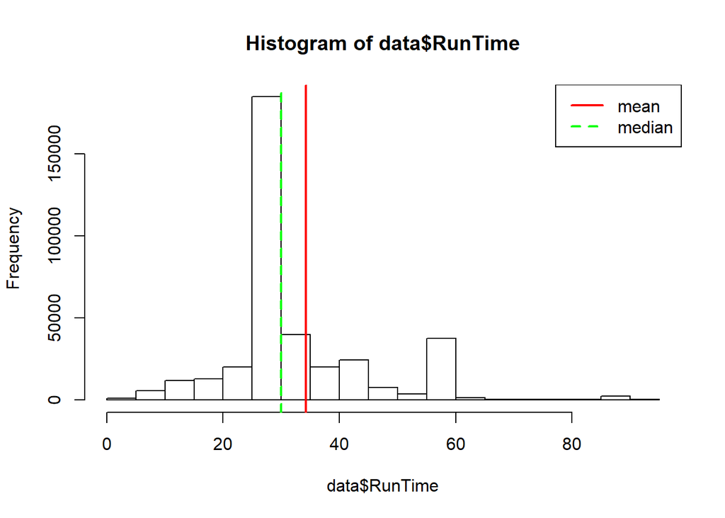

```r
hist(data$RunTime)
abline(v = mean(data$RunTime), col = "red", lwd = 2, lty = 1)
abline(v = median(data$RunTime), col = "green", lwd = 2, lty = 2)
legend("topright", legend = c("mean","median"), col = c("red","green"),
       lwd = c(2,2), lty = c(1,2))
```

We can see that there are some projects that take way longer than the mean or median, making the run time right skewd.

#### Next Step Considerations

For the purposes of this project, I propose we use only use kickstarters from the United States. Along with being the country with a large majority of the data set, it would remove undefined variable and that odd country name along with focusing on one currancy.

Since one of the statistical methods we will use is logistic regression, this eliminates country and currancy as predictors.

We still need to come up with another statistical methods to use and we need to form hypotheses to answer (Ex: If factor X important).